# Introduction

### Data description:

The data contains 110,527 records of patients that showed or not for the appointment. The table contains 14 columns (Characteristics) thay may affect if the patient will show or not.

### Columns:

- PatientId : Identification of a patient.
- AppointmentID : Identification for each appointment.
- Gender : Female or MAle.
- ScheduledDay : The day someone called or registered the appointment.
- AppointmentDay : The day of the actuall appointment.
- Age : Age of the patient.
- Neighbourhood : Where the appointment takes place.
- Scholarship : True of False.
- Hipertension : True of False.
- Diabetes : True of False.
- Alcoholism : True of False.
- Handcap : True of False.
- SMS_received : True of False.
- No-show : (Yes) means if the patient did not show for the appointment, (No) means if the patient show for the appointment.

# Data Wrangling

Steps:

- Loading the data.
- Check for NaN values.
- Solve the outlier.
- Change "PatientId" type from ( float ) to ( int ).
- Change the formate of "ScheduledDay" and "AppointmentDay".
- Solve Handcap Values.
- Reset indexes.

## Loading the data

```python
import numpy as np
import pandas as pd
import matplotlib.pyplot as plt
```

```python
# downloaded the data from kaggle ( https://www.kaggle.com/datasets/joniarroba/noshowappointments )
df = pd.read_csv("KaggleV2-May-2016.csv")
df.head()
```

|  | PatientId | AppointmentID | Gender | ScheduledDay | AppointmentDay | Age | Neighbourhood | Scholarship | Hipertension | Diabetes | Alcoholism | Handcap | SMS_received | No-show |
| --- | --- | --- | --- | --- | --- | --- | --- | --- | --- | --- | --- | --- | --- | --- |
| 0 | 2.987250e+13 | 5642903 | F | 2016-04-29T18:38:08Z | 2016-04-29T00:00:00Z | 62 | JARDIM DA PENHA | 0 | 1 | 0 | 0 | 0 | 0 | No |
| 1 | 5.589978e+14 | 5642503 | M | 2016-04-29T16:08:27Z | 2016-04-29T00:00:00Z | 56 | JARDIM DA PENHA | 0 | 0 | 0 | 0 | 0 | 0 | No |
| 2 | 4.262962e+12 | 5642549 | F | 2016-04-29T16:19:04Z | 2016-04-29T00:00:00Z | 62 | MATA DA PRAIA | 0 | 0 | 0 | 0 | 0 | 0 | No |
| 3 | 8.679512e+11 | 5642828 | F | 2016-04-29T17:29:31Z | 2016-04-29T00:00:00Z | 8 | PONTAL DE CAMBURI | 0 | 0 | 0 | 0 | 0 | 0 | No |
| 4 | 8.841186e+12 | 5642494 | F | 2016-04-29T16:07:23Z | 2016-04-29T00:00:00Z | 56 | JARDIM DA PENHA | 0 | 1 | 1 | 0 | 0 | 0 | No |

```python
df.info()
```

```
<class 'pandas.core.frame.DataFrame'>
RangeIndex: 110527 entries, 0 to 110526
Data columns (total 14 columns):
 #   Column          Non-Null Count   Dtype
---  ------          --------------   -----
 0   PatientId       110527 non-null  float64
 1   AppointmentID   110527 non-null  int64
 2   Gender          110527 non-null  object
 3   ScheduledDay    110527 non-null  object
 4   AppointmentDay  110527 non-null  object
 5   Age             110527 non-null  int64
 6   Neighbourhood   110527 non-null  object
 7   Scholarship     110527 non-null  int64
 8   Hipertension    110527 non-null  int64
 9   Diabetes        110527 non-null  int64
 10  Alcoholism      110527 non-null  int64
 11  Handcap         110527 non-null  int64
 12  SMS_received    110527 non-null  int64
 13  No-show         110527 non-null  object
dtypes: float64(1), int64(8), object(5)
memory usage: 11.8+ MB
```

```python
df.describe()
```

|  | PatientId | AppointmentID | Age | Scholarship | Hipertension | Diabetes | Alcoholism | Handcap | SMS_received |
| --- | --- | --- | --- | --- | --- | --- | --- | --- | --- |
| count | 1.105270e+05 | 1.105270e+05 | 110527.000000 | 110527.000000 | 110527.000000 | 110527.000000 | 110527.000000 | 110527.000000 | 110527.000000 |
| mean | 1.474963e+14 | 5.675305e+06 | 37.088874 | 0.098266 | 0.197246 | 0.071865 | 0.030400 | 0.022248 | 0.321026 |
| std | 2.560949e+14 | 7.129575e+04 | 23.110205 | 0.297675 | 0.397921 | 0.258265 | 0.171686 | 0.161543 | 0.466873 |
| min | 3.921784e+04 | 5.030230e+06 | -1.000000 | 0.000000 | 0.000000 | 0.000000 | 0.000000 | 0.000000 | 0.000000 |
| 25% | 4.172614e+12 | 5.640286e+06 | 18.000000 | 0.000000 | 0.000000 | 0.000000 | 0.000000 | 0.000000 | 0.000000 |
| 50% | 3.173184e+13 | 5.680573e+06 | 37.000000 | 0.000000 | 0.000000 | 0.000000 | 0.000000 | 0.000000 | 0.000000 |
| 75% | 9.439172e+13 | 5.725524e+06 | 55.000000 | 0.000000 | 0.000000 | 0.000000 | 0.000000 | 0.000000 | 1.000000 |
| max | 9.999816e+14 | 5.790484e+06 | 115.000000 | 1.000000 | 1.000000 | 1.000000 | 1.000000 | 4.000000 | 1.000000 |

```python
df.shape
```

```
(110527, 14)
```

```python
df.nunique()
```

```
PatientId          62299
AppointmentID     110527
Gender                 2
ScheduledDay      103549
AppointmentDay        27
Age                  104
Neighbourhood         81
Scholarship            2
Hipertension           2
Diabetes               2
Alcoholism             2
Handcap                5
SMS_received           2
No-show                2
dtype: int64
```

## Check if there is/are NaN values

```python
df.info()
```

```
<class 'pandas.core.frame.DataFrame'>
RangeIndex: 110527 entries, 0 to 110526
Data columns (total 14 columns):
 #   Column          Non-Null Count   Dtype
---  ------          --------------   -----
 0   PatientId       110527 non-null  float64
 1   AppointmentID   110527 non-null  int64
 2   Gender          110527 non-null  object
 3   ScheduledDay    110527 non-null  object
 4   AppointmentDay  110527 non-null  object
 5   Age             110527 non-null  int64
 6   Neighbourhood   110527 non-null  object
 7   Scholarship     110527 non-null  int64
 8   Hipertension    110527 non-null  int64
 9   Diabetes        110527 non-null  int64
 10  Alcoholism      110527 non-null  int64
 11  Handcap         110527 non-null  int64
 12  SMS_received    110527 non-null  int64
 13  No-show         110527 non-null  object
dtypes: float64(1), int64(8), object(5)
memory usage: 11.8+ MB
```

```python
# check if there is / are NaN values
df.isnull().sum()
```

```
PatientId         0
AppointmentID     0
Gender            0
ScheduledDay      0
AppointmentDay    0
Age               0
Neighbourhood     0
Scholarship       0
Hipertension      0
Diabetes          0
Alcoholism        0
Handcap           0
SMS_received      0
No-show           0
dtype: int64
```

```python
# make sure there is no NaN value/s
df.isnull().values.any()
```

```
False
```

## Solve the outlier of age = -1

```python
outlier = df[ df["Age"] == -1 ]
outlier
```

|  | PatientId | AppointmentID | Gender | ScheduledDay | AppointmentDay | Age | Neighbourhood | Scholarship | Hipertension | Diabetes | Alcoholism | Handcap | SMS_received | No-show |
| --- | --- | --- | --- | --- | --- | --- | --- | --- | --- | --- | --- | --- | --- | --- |
| 99832 | 4.659432e+14 | 5775010 | F | 2016-06-06T08:58:13Z | 2016-06-06T00:00:00Z | -1 | ROMÃO | 0 | 0 | 0 | 0 | 0 | 0 | No |

```python
# to get the full ID of the patient incase if the patient may booked other appointment/s or not
df["PatientId"].iloc[99832]
```

```
465943158731293.0
```

```python
# search for the patient if he/she has booked another appointment/s
df [ df["PatientId"] == 465943158731293]
```

|  | PatientId | AppointmentID | Gender | ScheduledDay | AppointmentDay | Age | Neighbourhood | Scholarship | Hipertension | Diabetes | Alcoholism | Handcap | SMS_received | No-show |
| --- | --- | --- | --- | --- | --- | --- | --- | --- | --- | --- | --- | --- | --- | --- |
| 99832 | 4.659432e+14 | 5775010 | F | 2016-06-06T08:58:13Z | 2016-06-06T00:00:00Z | -1 | ROMÃO | 0 | 0 | 0 | 0 | 0 | 0 | No |

```python
df.drop(99832, inplace = True)
```

```python
df.describe()
```

|  | PatientId | AppointmentID | Age | Scholarship | Hipertension | Diabetes | Alcoholism | Handcap | SMS_received |
| --- | --- | --- | --- | --- | --- | --- | --- | --- | --- |
| count | 1.105260e+05 | 1.105260e+05 | 110526.000000 | 110526.000000 | 110526.000000 | 110526.000000 | 110526.000000 | 110526.000000 | 110526.000000 |
| mean | 1.474934e+14 | 5.675304e+06 | 37.089219 | 0.098266 | 0.197248 | 0.071865 | 0.030400 | 0.022248 | 0.321029 |
| std | 2.560943e+14 | 7.129544e+04 | 23.110026 | 0.297676 | 0.397923 | 0.258266 | 0.171686 | 0.161543 | 0.466874 |
| min | 3.921784e+04 | 5.030230e+06 | 0.000000 | 0.000000 | 0.000000 | 0.000000 | 0.000000 | 0.000000 | 0.000000 |
| 25% | 4.172536e+12 | 5.640285e+06 | 18.000000 | 0.000000 | 0.000000 | 0.000000 | 0.000000 | 0.000000 | 0.000000 |
| 50% | 3.173184e+13 | 5.680572e+06 | 37.000000 | 0.000000 | 0.000000 | 0.000000 | 0.000000 | 0.000000 | 0.000000 |
| 75% | 9.438963e+13 | 5.725523e+06 | 55.000000 | 0.000000 | 0.000000 | 0.000000 | 0.000000 | 0.000000 | 1.000000 |
| max | 9.999816e+14 | 5.790484e+06 | 115.000000 | 1.000000 | 1.000000 | 1.000000 | 1.000000 | 4.000000 | 1.000000 |

```python
df.shape
```

```
(110526, 14)
```

## Change "PatientId" type from ( float ) to ( int ).

```python
df['PatientId'] = df['PatientId'].astype(int)
```

```python
df.info()
```

```
<class 'pandas.core.frame.DataFrame'>
Int64Index: 110526 entries, 0 to 110526
Data columns (total 14 columns):
 #   Column          Non-Null Count   Dtype
---  ------          --------------   -----
 0   PatientId       110526 non-null  int64
 1   AppointmentID   110526 non-null  int64
 2   Gender          110526 non-null  object
 3   ScheduledDay    110526 non-null  object
 4   AppointmentDay  110526 non-null  object
 5   Age             110526 non-null  int64
 6   Neighbourhood   110526 non-null  object
 7   Scholarship     110526 non-null  int64
 8   Hipertension    110526 non-null  int64
 9   Diabetes        110526 non-null  int64
 10  Alcoholism      110526 non-null  int64
 11  Handcap         110526 non-null  int64
 12  SMS_received    110526 non-null  int64
 13  No-show         110526 non-null  object
dtypes: int64(9), object(5)
memory usage: 12.6+ MB
```

## Change the formate of "ScheduledDay" and "AppointmentDay"

the "ScheduledDay" and "AppointmentDay" formate will be changed from (2016-04-29T18:38:08Z) to (2016-04-29).

- including only the date of "ScheduledDay" and "AppointmentDay".
- using to_datetime() function.

** using ( apply ) function instead of ( for loop ) will make the process more faster, and dividing the code into function will also faster the process [ I apply what I have learned during COOP ].

```python
# function to only take the date from a string
def func(i):
    x= i[:10]
    return x

# using apply function on both "ScheduledDay" and "AppointmentDay" to change their formate
df["ScheduledDay"] = df.apply(lambda x: func(x["ScheduledDay"]),axis=1)
df["AppointmentDay"] = df.apply(lambda x: func(x["AppointmentDay"]),axis=1)

# change the type from string to dateTime
df["ScheduledDay"] = pd.to_datetime(df["ScheduledDay"])
df["AppointmentDay"] = pd.to_datetime(df["AppointmentDay"])
```

```python
df.head(30)
```

|  | PatientId | AppointmentID | Gender | ScheduledDay | AppointmentDay | Age | Neighbourhood | Scholarship | Hipertension | Diabetes | Alcoholism | Handcap | SMS_received | No-show |
| --- | --- | --- | --- | --- | --- | --- | --- | --- | --- | --- | --- | --- | --- | --- |
| 0 | 29872499824296 | 5642903 | F | 2016-04-29 | 2016-04-29 | 62 | JARDIM DA PENHA | 0 | 1 | 0 | 0 | 0 | 0 | No |
| 1 | 558997776694438 | 5642503 | M | 2016-04-29 | 2016-04-29 | 56 | JARDIM DA PENHA | 0 | 0 | 0 | 0 | 0 | 0 | No |
| 2 | 4262962299951 | 5642549 | F | 2016-04-29 | 2016-04-29 | 62 | MATA DA PRAIA | 0 | 0 | 0 | 0 | 0 | 0 | No |
| 3 | 867951213174 | 5642828 | F | 2016-04-29 | 2016-04-29 | 8 | PONTAL DE CAMBURI | 0 | 0 | 0 | 0 | 0 | 0 | No |
| 4 | 8841186448183 | 5642494 | F | 2016-04-29 | 2016-04-29 | 56 | JARDIM DA PENHA | 0 | 1 | 1 | 0 | 0 | 0 | No |
| 5 | 95985133231274 | 5626772 | F | 2016-04-27 | 2016-04-29 | 76 | REPÚBLICA | 0 | 1 | 0 | 0 | 0 | 0 | No |
| 6 | 733688164476661 | 5630279 | F | 2016-04-27 | 2016-04-29 | 23 | GOIABEIRAS | 0 | 0 | 0 | 0 | 0 | 0 | Yes |
| 7 | 3449833394123 | 5630575 | F | 2016-04-27 | 2016-04-29 | 39 | GOIABEIRAS | 0 | 0 | 0 | 0 | 0 | 0 | Yes |
| 8 | 56394729949972 | 5638447 | F | 2016-04-29 | 2016-04-29 | 21 | ANDORINHAS | 0 | 0 | 0 | 0 | 0 | 0 | No |
| 9 | 78124564369297 | 5629123 | F | 2016-04-27 | 2016-04-29 | 19 | CONQUISTA | 0 | 0 | 0 | 0 | 0 | 0 | No |
| 10 | 734536231958495 | 5630213 | F | 2016-04-27 | 2016-04-29 | 30 | NOVA PALESTINA | 0 | 0 | 0 | 0 | 0 | 0 | No |
| 11 | 7542951368435 | 5620163 | M | 2016-04-26 | 2016-04-29 | 29 | NOVA PALESTINA | 0 | 0 | 0 | 0 | 0 | 1 | Yes |
| 12 | 566654781423437 | 5634718 | F | 2016-04-28 | 2016-04-29 | 22 | NOVA PALESTINA | 1 | 0 | 0 | 0 | 0 | 0 | No |
| 13 | 911394617215919 | 5636249 | M | 2016-04-28 | 2016-04-29 | 28 | NOVA PALESTINA | 0 | 0 | 0 | 0 | 0 | 0 | No |
| 14 | 99884723334928 | 5633951 | F | 2016-04-28 | 2016-04-29 | 54 | NOVA PALESTINA | 0 | 0 | 0 | 0 | 0 | 0 | No |
| 15 | 99948393975 | 5620206 | F | 2016-04-26 | 2016-04-29 | 15 | NOVA PALESTINA | 0 | 0 | 0 | 0 | 0 | 1 | No |
| 16 | 84574392942817 | 5633121 | M | 2016-04-28 | 2016-04-29 | 50 | NOVA PALESTINA | 0 | 0 | 0 | 0 | 0 | 0 | No |
| 17 | 14794966191172 | 5633460 | F | 2016-04-28 | 2016-04-29 | 40 | CONQUISTA | 1 | 0 | 0 | 0 | 0 | 0 | Yes |
| 18 | 17135378245248 | 5621836 | F | 2016-04-26 | 2016-04-29 | 30 | NOVA PALESTINA | 1 | 0 | 0 | 0 | 0 | 1 | No |
| 19 | 7223289184215 | 5640433 | F | 2016-04-29 | 2016-04-29 | 46 | DA PENHA | 0 | 0 | 0 | 0 | 0 | 0 | No |
| 20 | 622257462899397 | 5626083 | F | 2016-04-27 | 2016-04-29 | 30 | NOVA PALESTINA | 0 | 0 | 0 | 0 | 0 | 0 | Yes |
| 21 | 12154843752835 | 5628338 | F | 2016-04-27 | 2016-04-29 | 4 | CONQUISTA | 0 | 0 | 0 | 0 | 0 | 0 | Yes |
| 22 | 863229818887631 | 5616091 | M | 2016-04-25 | 2016-04-29 | 13 | CONQUISTA | 0 | 0 | 0 | 0 | 0 | 1 | Yes |
| 23 | 213753979425692 | 5634142 | F | 2016-04-28 | 2016-04-29 | 46 | CONQUISTA | 0 | 0 | 0 | 0 | 0 | 0 | No |
| 24 | 8734857996885 | 5641780 | F | 2016-04-29 | 2016-04-29 | 65 | TABUAZEIRO | 0 | 0 | 0 | 0 | 0 | 0 | No |
| 25 | 5819369978796 | 5624020 | M | 2016-04-26 | 2016-04-29 | 46 | CONQUISTA | 0 | 1 | 0 | 0 | 0 | 1 | No |
| 26 | 25787851512 | 5641781 | F | 2016-04-29 | 2016-04-29 | 45 | BENTO FERREIRA | 0 | 1 | 0 | 0 | 0 | 0 | No |
| 27 | 12154843752835 | 5628345 | F | 2016-04-27 | 2016-04-29 | 4 | CONQUISTA | 0 | 0 | 0 | 0 | 0 | 0 | No |
| 28 | 5926171692527 | 5642400 | M | 2016-04-29 | 2016-04-29 | 51 | SÃO PEDRO | 0 | 0 | 0 | 0 | 0 | 0 | No |
| 29 | 1225776163665 | 5642186 | F | 2016-04-29 | 2016-04-29 | 32 | SANTA MARTHA | 0 | 0 | 0 | 0 | 0 | 0 | No |

```python
df.info()
```

```
<class 'pandas.core.frame.DataFrame'>
Int64Index: 110526 entries, 0 to 110526
Data columns (total 14 columns):
 #   Column          Non-Null Count   Dtype
---  ------          --------------   -----
 0   PatientId       110526 non-null  int64
 1   AppointmentID   110526 non-null  int64
 2   Gender          110526 non-null  object
 3   ScheduledDay    110526 non-null  datetime64[ns]
 4   AppointmentDay  110526 non-null  datetime64[ns]
 5   Age             110526 non-null  int64
 6   Neighbourhood   110526 non-null  object
 7   Scholarship     110526 non-null  int64
 8   Hipertension    110526 non-null  int64
 9   Diabetes        110526 non-null  int64
 10  Alcoholism      110526 non-null  int64
 11  Handcap         110526 non-null  int64
 12  SMS_received    110526 non-null  int64
 13  No-show         110526 non-null  object
dtypes: datetime64[ns](2), int64(9), object(3)
memory usage: 12.6+ MB
```

## Solve Handcap Values

By converting [ 2 , 3 , 4 ] to 1.

```python
df["Handcap"].value_counts()
```

```
0    108285
1      2042
2       183
3        13
4         3
Name: Handcap, dtype: int64
```

```python
df["Handcap"] = df["Handcap"].replace([2,3,4],1)
```

#### Check for "Handcap" values

```python
df["Handcap"].value_counts()
```

```
0    108285
1      2241
Name: Handcap, dtype: int64
```

```python
df.describe()
```

|  | PatientId | AppointmentID | Age | Scholarship | Hipertension | Diabetes | Alcoholism | Handcap | SMS_received |
| --- | --- | --- | --- | --- | --- | --- | --- | --- | --- |
| count | 1.105260e+05 | 1.105260e+05 | 110526.000000 | 110526.000000 | 110526.000000 | 110526.000000 | 110526.000000 | 110526.000000 | 110526.000000 |
| mean | 1.474934e+14 | 5.675304e+06 | 37.089219 | 0.098266 | 0.197248 | 0.071865 | 0.030400 | 0.020276 | 0.321029 |
| std | 2.560943e+14 | 7.129544e+04 | 23.110026 | 0.297676 | 0.397923 | 0.258266 | 0.171686 | 0.140943 | 0.466874 |
| min | 3.921700e+04 | 5.030230e+06 | 0.000000 | 0.000000 | 0.000000 | 0.000000 | 0.000000 | 0.000000 | 0.000000 |
| 25% | 4.172536e+12 | 5.640285e+06 | 18.000000 | 0.000000 | 0.000000 | 0.000000 | 0.000000 | 0.000000 | 0.000000 |
| 50% | 3.173184e+13 | 5.680572e+06 | 37.000000 | 0.000000 | 0.000000 | 0.000000 | 0.000000 | 0.000000 | 0.000000 |
| 75% | 9.438963e+13 | 5.725523e+06 | 55.000000 | 0.000000 | 0.000000 | 0.000000 | 0.000000 | 0.000000 | 1.000000 |
| max | 9.999816e+14 | 5.790484e+06 | 115.000000 | 1.000000 | 1.000000 | 1.000000 | 1.000000 | 1.000000 | 1.000000 |

## Reset indexes

```python
df = df.reset_index()
```

```python
df
```

|  | index | PatientId | AppointmentID | Gender | ScheduledDay | AppointmentDay | Age | Neighbourhood | Scholarship | Hipertension | Diabetes | Alcoholism | Handcap | SMS_received | No-show |
| --- | --- | --- | --- | --- | --- | --- | --- | --- | --- | --- | --- | --- | --- | --- | --- |
| 0 | 0 | 29872499824296 | 5642903 | F | 2016-04-29 | 2016-04-29 | 62 | JARDIM DA PENHA | 0 | 1 | 0 | 0 | 0 | 0 | No |
| 1 | 1 | 558997776694438 | 5642503 | M | 2016-04-29 | 2016-04-29 | 56 | JARDIM DA PENHA | 0 | 0 | 0 | 0 | 0 | 0 | No |
| 2 | 2 | 4262962299951 | 5642549 | F | 2016-04-29 | 2016-04-29 | 62 | MATA DA PRAIA | 0 | 0 | 0 | 0 | 0 | 0 | No |
| 3 | 3 | 867951213174 | 5642828 | F | 2016-04-29 | 2016-04-29 | 8 | PONTAL DE CAMBURI | 0 | 0 | 0 | 0 | 0 | 0 | No |
| 4 | 4 | 8841186448183 | 5642494 | F | 2016-04-29 | 2016-04-29 | 56 | JARDIM DA PENHA | 0 | 1 | 1 | 0 | 0 | 0 | No |
| ... | ... | ... | ... | ... | ... | ... | ... | ... | ... | ... | ... | ... | ... | ... | ... |
| 110521 | 110522 | 2572134369293 | 5651768 | F | 2016-05-03 | 2016-06-07 | 56 | MARIA ORTIZ | 0 | 0 | 0 | 0 | 0 | 1 | No |
| 110522 | 110523 | 3596266328735 | 5650093 | F | 2016-05-03 | 2016-06-07 | 51 | MARIA ORTIZ | 0 | 0 | 0 | 0 | 0 | 1 | No |
| 110523 | 110524 | 15576631729893 | 5630692 | F | 2016-04-27 | 2016-06-07 | 21 | MARIA ORTIZ | 0 | 0 | 0 | 0 | 0 | 1 | No |
| 110524 | 110525 | 92134931435557 | 5630323 | F | 2016-04-27 | 2016-06-07 | 38 | MARIA ORTIZ | 0 | 0 | 0 | 0 | 0 | 1 | No |
| 110525 | 110526 | 377511518121127 | 5629448 | F | 2016-04-27 | 2016-06-07 | 54 | MARIA ORTIZ | 0 | 0 | 0 | 0 | 0 | 1 | No |

110526 rows × 15 columns

# Exploratory Data Analysis

## Does The Gender May Affect If the patient Will Show Up For The Appointment or Not?

```python
df_F_not_show = df[ (df["Gender"]=="F") &  (df["No-show"]=="Yes")]
df_F_show  = df[ (df["Gender"]=="F") &  (df["No-show"]=="No") ]

df_M_not_show = df[ (df["Gender"]=="M") &  (df["No-show"]=="Yes")]
df_M_show  = df[ (df["Gender"]=="M") &  (df["No-show"]=="No") ]
```

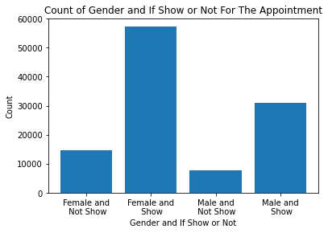

```python
plt.bar([1, 2, 3, 4], [len(df_F_not_show), len(df_F_show), len(df_M_not_show), len(df_M_show)],
        tick_label=["Female and\n Not Show", "Female and\n Show", "Male and\n Not Show", "Male and\n Show"])
plt.title('Count of Gender and If Show or Not For The Appointment')
plt.xlabel('Gender and If Show or Not')
plt.ylabel('Count');
```

***Note : But here becuase the number of female does not equal to male, we get the proportion for each gender so it will be out of 1 for each.

```python
# getting the total number of female and male
total_female = len(df_F_not_show) + len(df_F_show)
total_male = len(df_M_not_show) + len(df_M_show)

#proportion for female
prop_F_not_show = len(df_F_not_show)/total_female
prop_F_show = len(df_F_show)/total_female

#proportion for male
prop_M_not_show = len(df_M_not_show)/total_male
prop_M_show = len(df_M_show)/total_male
```

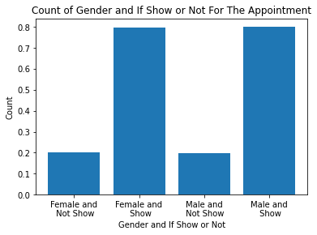

```python
plt.bar([1, 2, 3, 4], [prop_F_not_show, prop_F_show, prop_M_not_show, prop_M_show],
        tick_label=["Female and\n Not Show", "Female and\n Show", "Male and\n Not Show", "Male and\n Show"])
plt.title('Count of Gender and If Show or Not For The Appointment')
plt.xlabel('Gender and If Show or Not')
plt.ylabel('Count');
```

Now we can see tha bot female and male have approximately same percentage of showing to the appointment. Also, both female and male have approximately same percentage of not showing to the appointnent.

## Does Younger Patients Show Up To The Appointment More Than Older Patients or Not?

```python
No_Show_not_show = df["No-show"] == "Yes"
No_Show_show = df["No-show"]== "No"
```

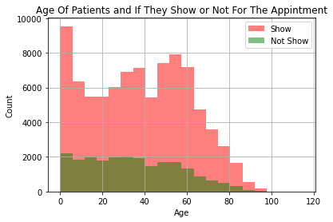

```python
df.Age[No_Show_show].hist(alpha=0.5, bins=20, label='Show' , color="red") # patient show for the appointment
df.Age[No_Show_not_show].hist(alpha=0.5,bins=20, label='Not Show' , color="green")#patient did no show for the appointment

plt.title('Age Of Patients and If They Show or Not For The Appintment')
plt.xlabel('Age')
plt.ylabel('Count');
plt.legend();
# younger are more likely to show for the appointment
```

## Does Having A Scholarship Affect If The Patient Will Show For The Appointment or Not?

```python
df["Scholarship"].value_counts()
```

```
0    99665
1    10861
Name: Scholarship, dtype: int64
```

```python
df_s_not_show = df[ (df["Scholarship"]==1) &  (df["No-show"]=="Yes")]
df_s_show  = df[ (df["Scholarship"]==1) &  (df["No-show"]=="No") ]

df_n_not_show = df[ (df["Scholarship"]==0) &  (df["No-show"]=="Yes")]
df_n_show  = df[ (df["Scholarship"]==0) &  (df["No-show"]=="No") ]
```

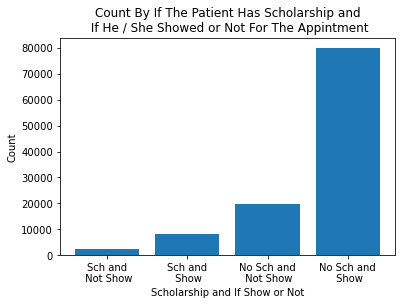

```python
plt.bar([1, 2, 3, 4], [len(df_s_not_show), len(df_s_show), len(df_n_not_show), len(df_n_show)],
        tick_label=["Sch and\n Not Show", "Sch and\n Show", "No Sch and\n Not Show", "No Sch and\n Show"])
plt.title('Count By If The Patient Has Scholarship and\n If He / She Showed or Not For The Appintment')
plt.xlabel('Scholarship and If Show or Not')
plt.ylabel('Count');
```

## Does Sending an SMS Will Increase The Prcentage Of Showing Up To The Appointment?

```python
df["SMS_received"].value_counts()
```

```
0    75044
1    35482
Name: SMS_received, dtype: int64
```

```python
sms_not_show = df[ (df["SMS_received"]==1) &  (df["No-show"]=="Yes")]
sms_show  = df[ (df["SMS_received"]==1) &  (df["No-show"]=="No") ]

n_sms_not_show = df[ (df["SMS_received"]==0) &  (df["No-show"]=="Yes")]
n_sms_show  = df[ (df["SMS_received"]==0) &  (df["No-show"]=="No") ]
```

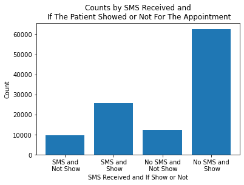

```python
plt.bar([1, 2, 3, 4], [len(sms_not_show), len(sms_show), len(n_sms_not_show), len(n_sms_show)],
        tick_label=["SMS and\n Not Show",
                    "SMS and\n Show",
                    "No SMS and\n Not Show",
                    "No SMS and\n Show"])
plt.title("Counts by SMS Received and\n If The Patient Showed or Not For The Appointment")
plt.xlabel('SMS Received and If Show or Not')
plt.ylabel('Count');
```

Here we can see that most of patients showed up for their appointment did not received an SMS message in the first rank, and in the second rank are patients who received an SMS message and showed up for their appointment.

# Conclusion: